# Project 2: Data Mining, Classification, Prediction

SDS322E

# Mining, Classification, Prediction

## Kinjal Gajera, kg28752

### Introduction

The dataset I chose was the ‘insurance’ which contains information over age, sex, bmi, number of children, smoker status, region, and insurance charges. It was found through the website, www.kaggle.com. This dataset also includes 1,338 observation for each variable with 2 of them (sex and smoker status) being binary variables, 1 (region) being categorical varibale, and 4 (age, bmi, number of children, and insurance charges) being numerical variables. These variables are interesting to me because I have relatives who have increased insurance charges due to smoker status and bmi. This dataset can be used to determine how accurate the relationships are between all the variables and insurance charges.

```r
library(tidyverse)
insurance <- read_csv("insurance.csv")
view(insurance)
```

### Cluster Analysis

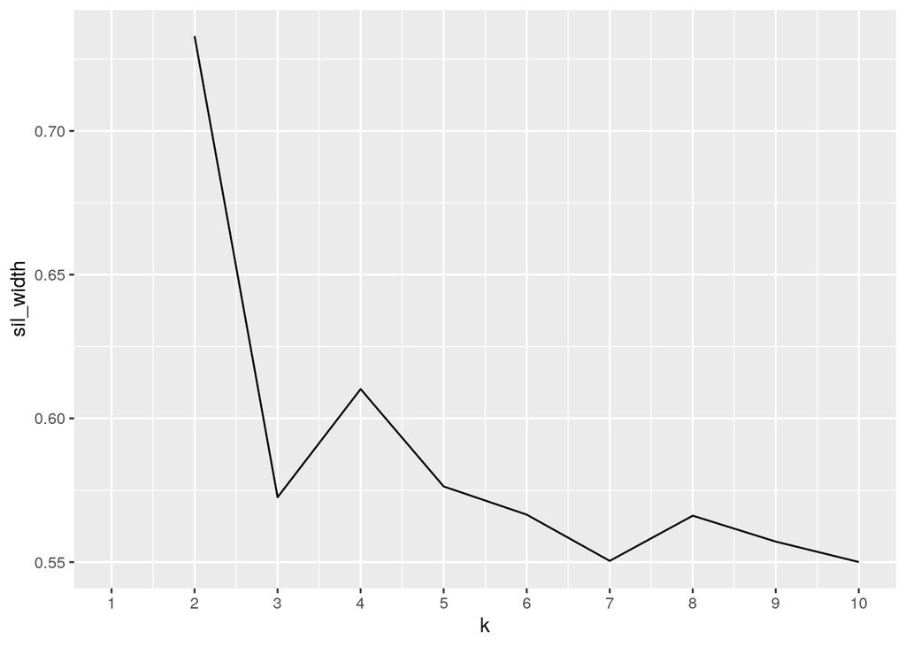

```r
library(cluster)
library(ggplot2)
library(GGally)

pam_dat <- insurance %>% select(age, bmi, charges)
sil_width <- vector()
for (i in 2:10) {
    pam_fit <- pam(pam_dat, k = i)
    sil_width[i] <- pam_fit$silinfo$avg.width
}
ggplot() + geom_line(aes(x = 1:10, y = sil_width)) + scale_x_continuous(name = "k",
    breaks = 1:10)
```

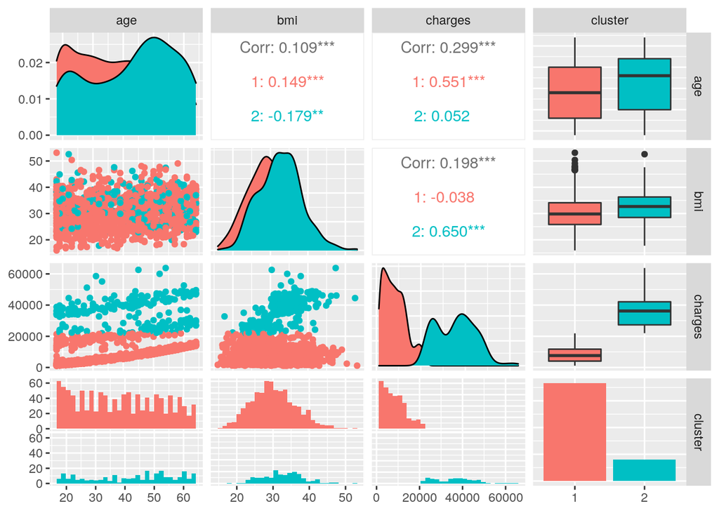

```r
pam1 <- pam_dat %>% pam(k = 2)

pamclust <- pam_dat %>% mutate(cluster = as.factor(pam1$clustering))
ggpairs(pamclust, mapping = aes(color = cluster))
```

### Dimensionality Reduction with PCA

```r
pam_nums <- insurance %>% select_if(is.numeric) %>% scale
pam_pca <- princomp(pam_nums, cor = T)
summary(pam_pca, loadings = T)
```

```
## Importance of components:
##                           Comp.1    Comp.2    Comp.3    Comp.4
## Standard deviation     1.1950185 0.9962400 0.9468493 0.8263855
## Proportion of Variance 0.3570173 0.2481235 0.2241309 0.1707283
## Cumulative Proportion  0.3570173 0.6051408 0.8292717 1.0000000
##
## Loadings:
##          Comp.1 Comp.2 Comp.3 Comp.4
## age       0.586         0.535  0.608
## bmi       0.455  0.279 -0.806  0.256
## children  0.175 -0.959 -0.212
## charges   0.648         0.140 -0.748
```

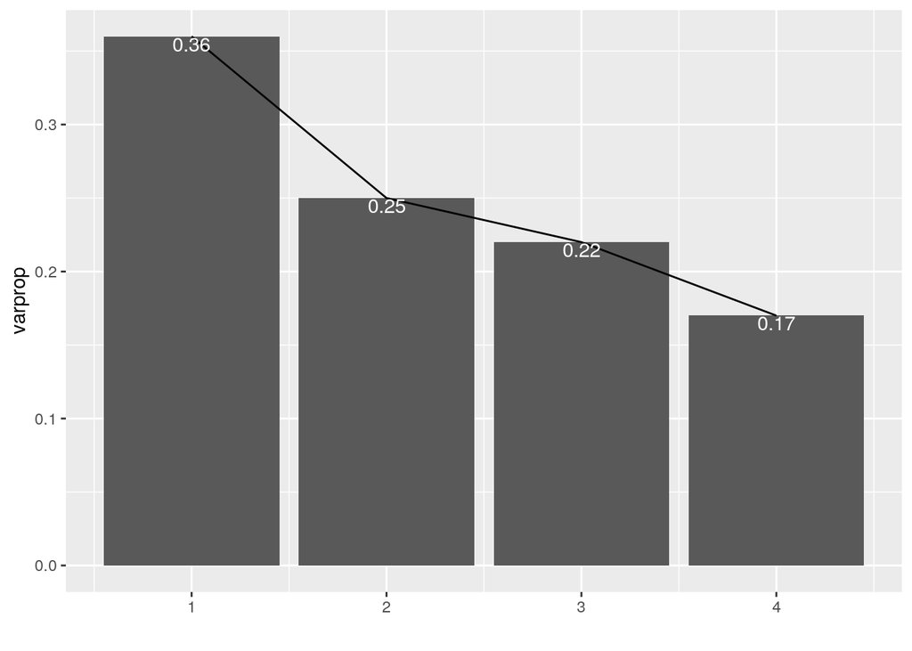

```r
eigval <- pam_pca$sdev^2
varprop = round(eigval/sum(eigval), 2)

ggplot() + geom_bar(aes(y = varprop, x = 1:4), stat = "identity") +
    xlab("") + scale_x_continuous(breaks = 1:10) + geom_path(aes(x = 1:4,
    y = varprop)) + geom_text(aes(x = 1:4, y = varprop, label = round(varprop,
    2)), vjust = 1, col = "white")
```

```r
round(cumsum(eigval)/sum(eigval), 2)
```

```
## Comp.1 Comp.2 Comp.3 Comp.4
##   0.36   0.61   0.83   1.00
```

### Linear Classifier

```r
class_dat <- insurance %>% mutate(smoker = ifelse(smoker == "yes",
    1, 0))
class_dat <- class_dat %>% mutate(sex = ifelse(sex == "female",
    1, 0))
class_dat <- class_dat %>% select_if(is.numeric)

glm(smoker ~ ., data = class_dat, family = "binomial")
```

```
##
## Call:  glm(formula = smoker ~ ., family = "binomial", data = class_dat)
##
## Coefficients:
## (Intercept)          age          sex          bmi     children      charges
##   6.0560088   -0.0998327   -0.5459768   -0.3622420   -0.2424749    0.0003933
##
## Degrees of Freedom: 1337 Total (i.e. Null);  1332 Residual
## Null Deviance:       1357
## Residual Deviance: 305.2     AIC: 317.2
```

```r
fit <- glm(smoker ~ ., data = class_dat, family = "binomial")
probs <- predict(fit, type = "response")
class_diag(probs, class_dat$smoker, positive = 1)
```

```
##            acc   sens   spec    ppv     f1     ba    auc
## Metrics 0.9574 0.9307 0.9643 0.8703 0.8995 0.9475 0.9867
```

```r
table(truth = class_dat$smoker, predictions = probs > 0.5)
```

```
##      predictions
## truth FALSE TRUE
##     0  1026   38
##     1    19  255
```

```r
library(caret)

set.seed(1234)
k = 10

class_dat$smoker = as.factor(class_dat$smoker)

data <- class_dat[sample(nrow(class_dat)), ]  #randomly order rows
folds <- cut(seq(1:nrow(class_dat)), breaks = k, labels = F)  #create 10 folds
diags <- NULL

for (i in 1:k) {
    train <- data[folds != i, ]
    test <- data[folds == i, ]
    truth <- test$smoker
    ## Train model on training set
    fit <- glm(smoker ~ ., data = train, family = "binomial")
    probs <- predict(fit, newdata = test, type = "response")
    ## Test model on test set (save all k results)
    diags <- rbind(diags, class_diag(probs, truth, positive = 1))
}

summarize_all(diags, mean)
```

```
##       acc   sens    spec     ppv      f1      ba     auc
## 1 0.95738 0.9337 0.96352 0.87378 0.89874 0.94859 0.98685
```

Looking at our CV model, we see that it has a mean AUC of greater than 0.95. This means that across all 10 folds the model performed exceptional well on average. This is important to know as our non CV model performed exceptionally well as well. However, this is most likely due to the fact that the model has seen the data it is being tested on. In the case of cross validation, the model has to perform on a fold it has not been trained on. Performing well on this unseen fold is an indicator that our model is not overfitting.